# Fleet Object Plots

## Fleet Parameters

### Future Catchability

#### Sampled Parameters

Histograms of 200 simulations of inter-annual variability in fishing efficiency (`qcv`) and average annual change in fishing efficiency (`qinc`), with vertical colored lines indicating 3 randomly drawn values used in the time-series plot:

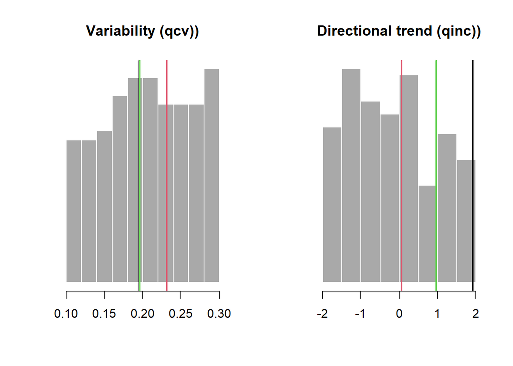

#### Time-Series

Time-series plot showing 3 trends in future fishing efficiency (catchability):

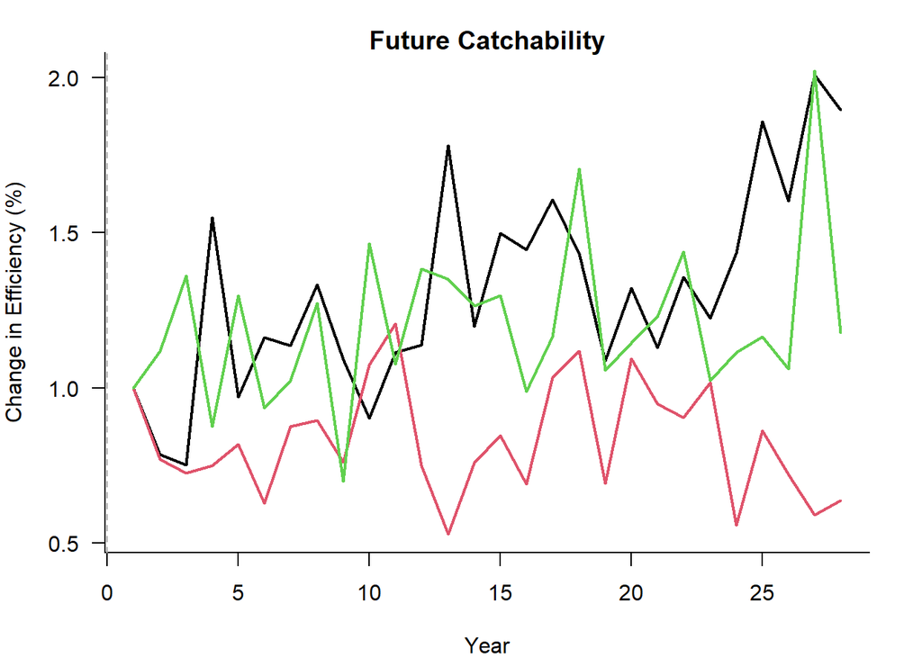

### Historical Effort

#### Sampled Parameters

Histograms of 200 simulations of inter-annual variability in historical fishing mortality (`Esd`), with vertical colored lines indicating 3 randomly drawn values used in the time-series plot:

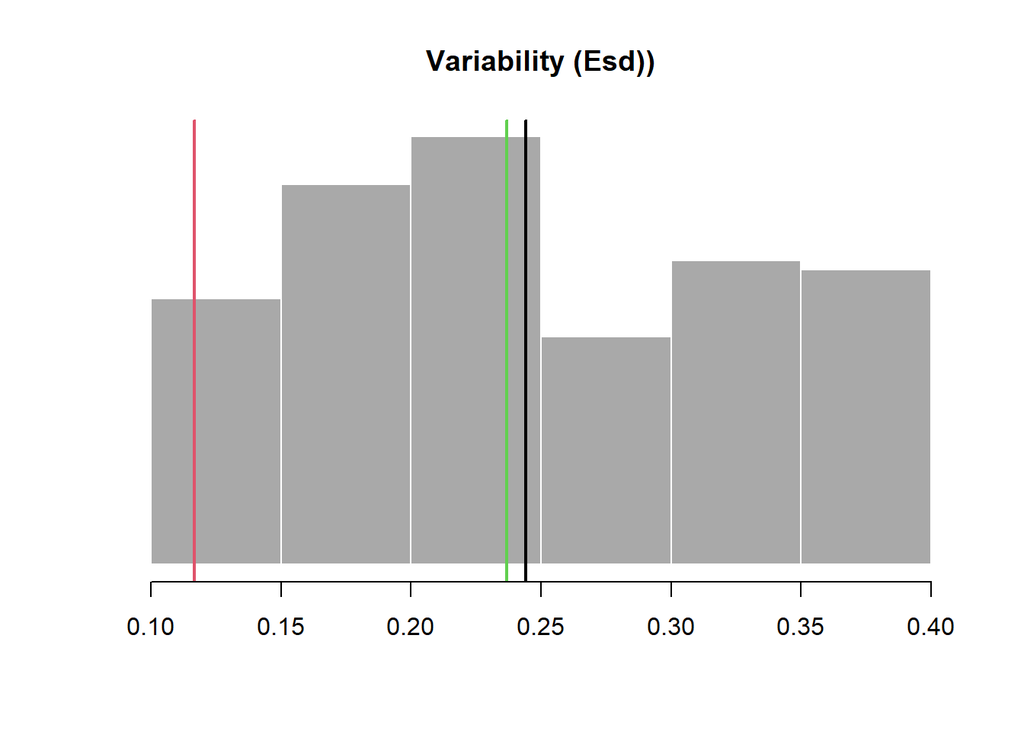

#### Time-Series

Time-series plot showing 3 trends in historical fishing mortality (`OM@EffUpper` and `OM@EffLower` or `OM@cpars$Find`):

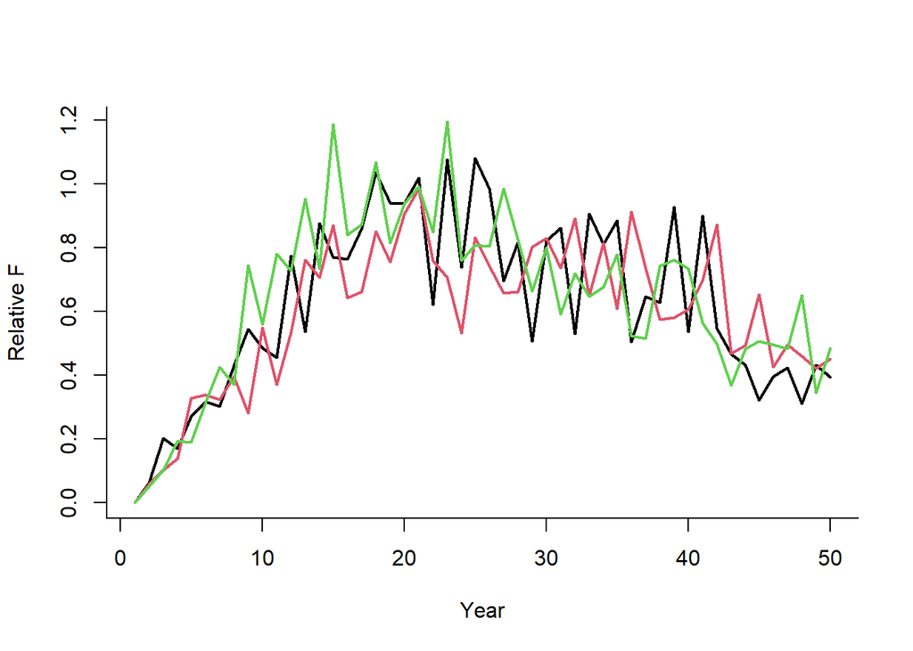

### Historical MPA & Spatial Targeting

#### Existing Spatial Closures

CURRENTLY NOT IMPLEMENTED !

#### Spatial Targeting

Histograms of 200 simulations of spatial targeting parameter (`Spat_targ`), with vertical colored lines indicating 3 randomly drawn values:

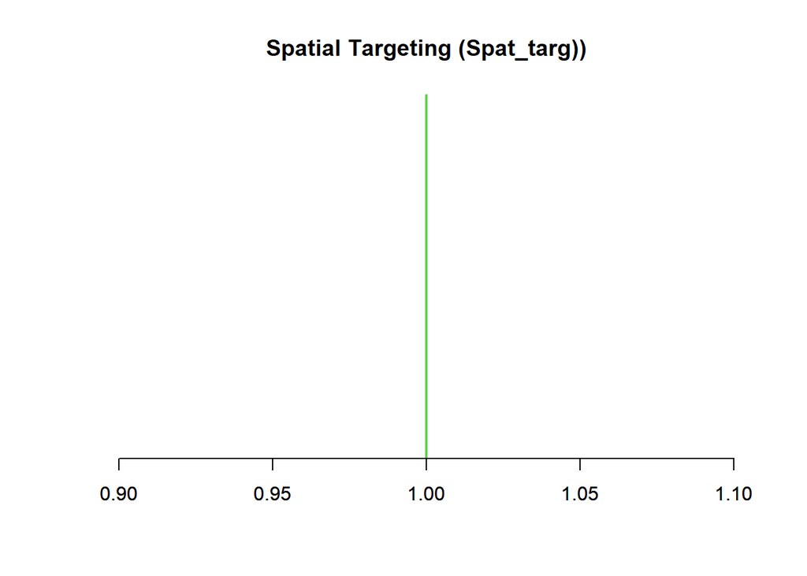

### Selectivity and Retention

#### Sampled Selectivity Parameters

Histograms of simulations of length at 5% selection (`L5`), first length at full selection (`LFS`), and vulnerability of animals at mean asymptotic length (`Vmaxlen`) for the first historical year, the last historical year, and the last projection year, wtih vertical colored lines indicating 3 randomly drawn values used in the other plots:

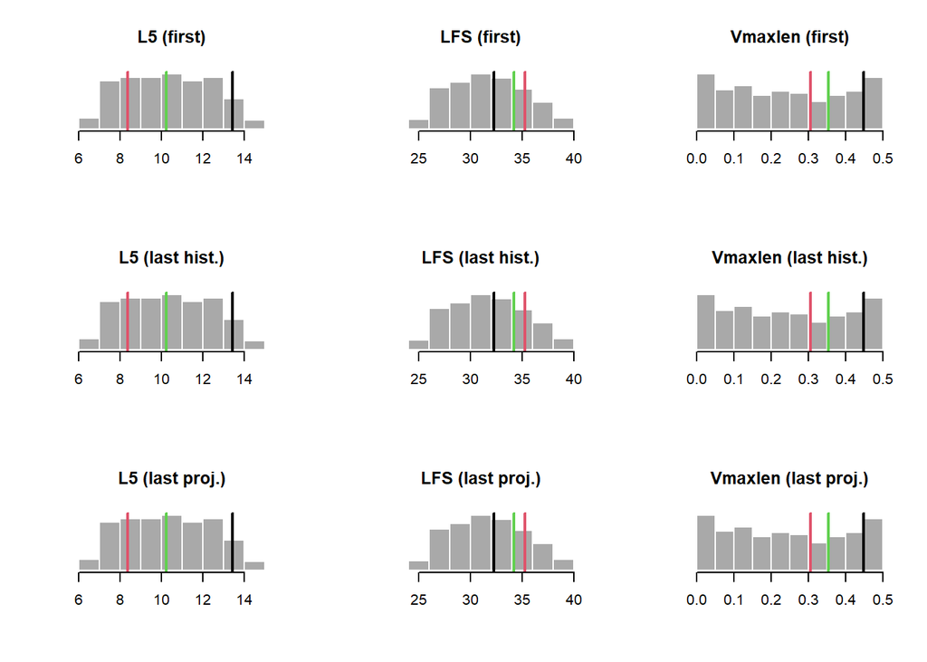

#### Sampled Retention Parameters

Histograms of simulations of length at 5% retention (`LR5`), first length at full retention (`LFR`), and retention of animals at mean asymptotic length (`Rmaxlen`) for the first historical year, the last historical year, and the last projection year, wtih vertical colored lines indicating 3 randomly drawn values used in the other plots:

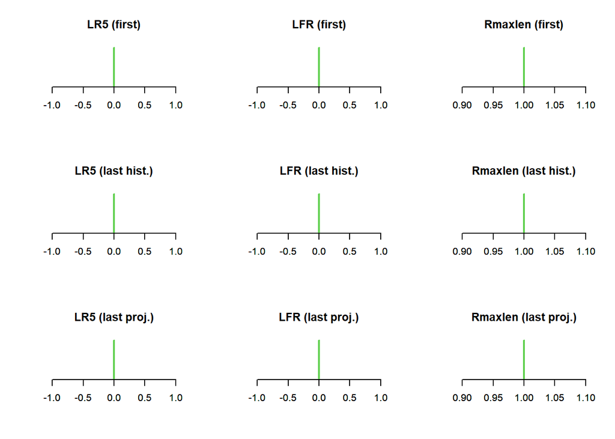

#### Selectivity & Retention at Length

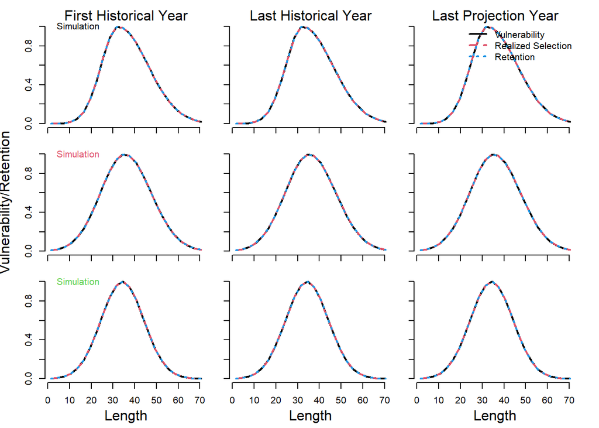

#### Selectivity & Retention at Age

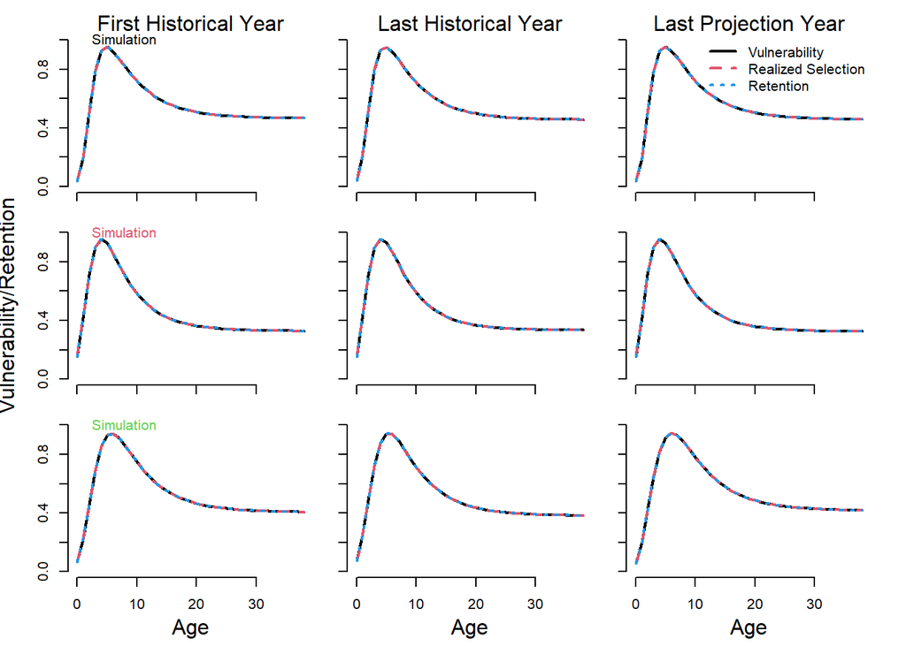